# Dummy Variables and Non-Linear Models

EC 325: Econometrics

Prof. Caraher

Colby College

Oct 22, 2026

# Dummy Variables

## What Are Dummy Variables?

- So far we’ve used **quantitative** regressors: wages, education, experience…
- But many important variables are **qualitative**: race, gender, region, program participation
- A **dummy variable** (aka indicator or binary variable) translates **qualitative info into numbers**:

$$D = \begin{cases} 1 & \text{if the characteristic is present} \\ 0 & \text{otherwise} \end{cases}$$

- Examples: $female = 1$ if female, $south = 1$ if in the South, $treated = 1$ if in treatment group

## What Does a Dummy Look Like?

- Suppose we want to know the effect of completing calculus in high school on college Economics test grades
- We might have data that looks like this:

```
  score hsgpa hs_math_level
1 84.43 3.355      calculus
2 57.38 3.219       algebra
3 66.39 3.306      calculus
4 81.15 3.977      calculus
5 95.90 3.890      calculus
6 83.61 3.500      calculus
```

- We can’t put `hs_math_level` in a regression directly, but we *can* recode it as a dummy:

$$Calculus_i = \begin{cases} 1 & \text{if student $i$ took calculus in high school} \\ 0 & \text{otherwise} \end{cases}$$

## Creating a Dummy Variable with `case_when()`

```r
case_when(
  condition1 ~ value1,
  condition2 ~ value2,
  TRUE       ~ default_value
)
```

- Each line is a **condition ~ value** pair, checked top to bottom
- `TRUE ~ ...` is a catch-all “else”
- Careful: `TRUE ~ 0` also turns **missing** values into 0

```r
econmath_data <- econmath_data |>
  mutate(calculus = case_when(
    hs_math_level == "calculus" ~ 1,
    hs_math_level == "algebra"  ~ 0
  ))

head(econmath_data, 4)
```

```
  score hsgpa hs_math_level calculus
1 84.43 3.355      calculus        1
2 57.38 3.219       algebra        0
3 66.39 3.306      calculus        1
4 81.15 3.977      calculus        1
```

## Interpreting Dummy Coefficients

- Say we want to estimate the following regression:

$$score = \beta_0 + \beta_1(hsgpa) + \beta_2(calculus) + \mu$$

- We simply include the dummy variable on the RHS!

```r
lm1 <- lm(score ~ hsgpa + calculus, data = econmath_data)
printCoefmat(coef(summary(lm1)), digits = 3)
```

```
            Estimate Std. Error t value Pr(>|t|)
(Intercept)   24.528      4.076    6.02  2.6e-09 ***
hsgpa         13.204      1.226   10.77  < 2e-16 ***
calculus       5.824      0.899    6.48  1.6e-10 ***
---
Signif. codes:  0 '***' 0.001 '**' 0.01 '*' 0.05 '.' 0.1 ' ' 1
```

- $\hat{\beta}_2 \approx 5.8$: Students who took calculus score **5.8 points higher** on average *relative to those who didn’t*, *holding GPA constant*
- Is that the *effect* of calculus? Only if nothing else that differs between the groups (motivation, math ability) also affects scores (Unit 5)

## What Dummies Do: Two Regression Lines

- Start with our model: $\widehat{score} = \hat{\beta}_0 + \hat{\beta}_1(hsgpa) + \hat{\beta}_2(calculus)$
- **Plug in** $calculus = 0$ (no calculus):

$$\widehat{score} = \hat{\beta}_0 + \hat{\beta}_1(hsgpa) + \hat{\beta}_2(0) = \hat{\beta}_0 + \hat{\beta}_1(hsgpa)$$

- **Plug in** $calculus = 1$ (took calculus):

$$\widehat{score} = \hat{\beta}_0 + \hat{\beta}_1(hsgpa) + \hat{\beta}_2(1) = \underbrace{(\hat{\beta}_0 + \hat{\beta}_2)}_{\text{new intercept}} + \hat{\beta}_1(hsgpa)$$

**The Key**

Both groups have the **same slope** ($\hat{\beta}_1$) — the effect of GPA is the same for both. But the calculus group’s line is shifted **up** by exactly $\hat{\beta}_2$. (Different slopes? That’s Unit 8.)

## What Dummies Do: A Picture

- Dummy variables essentially allow for a *separate intercept* for each value of your qualitative variables (i.e., each group!)

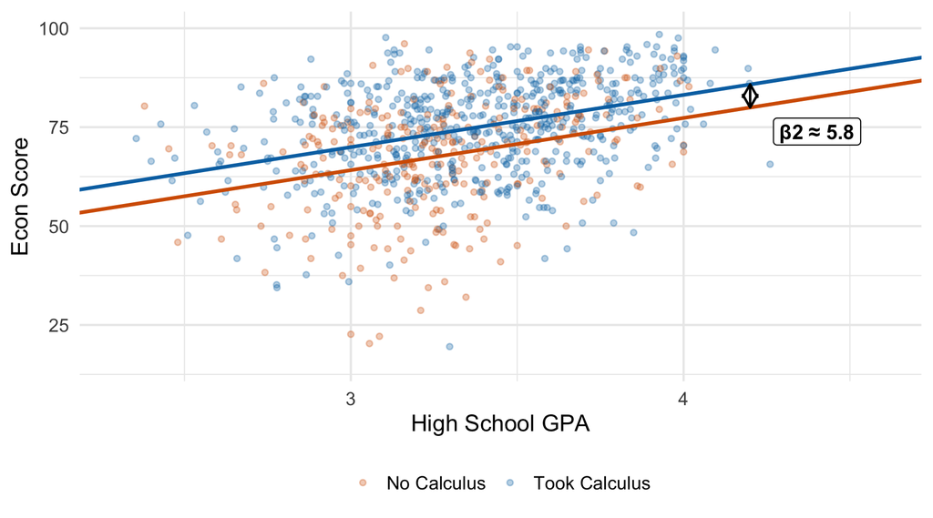

## The Dummy Variable Trap

Why not include dummies for **both** groups?

$$score = \beta_0 + \beta_2(calculus) + \beta_3(no\_calculus) + \mu$$

- For every observation: $calculus + no\_calculus = 1$
- Re-writing this, we can see: $calculus = 1 - no\_calculus$
- $calculus$ is an exact linear function of the intercept’s “1” and $no\_calculus$: **perfect multicollinearity**
- R won’t error: `lm()` silently drops one and reports its coefficient as `NA`

**The Rule**

We must always **omit one group** when including dummy variables. The omitted category is the **baseline** (reference group).

## Multiple Categories

- Effect of a penguin’s body mass on flipper length, *controlling for species*
- But `species` has **three** values: Adelie (152), Chinstrap (68), Gentoo (124)
- With $g$ categories, we create $g - 1$ dummies:

```r
penguins <- penguins |>
  mutate(
    chinstrap = case_when(species == "Chinstrap" ~ 1, TRUE ~ 0),
    gentoo    = case_when(species == "Gentoo"    ~ 1, TRUE ~ 0)
  )

set.seed(42)
penguins |>
  slice_sample(n = 5) |>
  select(flipper_length_mm, body_mass_g, species, chinstrap, gentoo)
```

```
# A tibble: 5 × 5
  flipper_length_mm body_mass_g species   chinstrap gentoo
              <int>       <int> <fct>         <dbl>  <dbl>
1               190        3450 Adelie            0      0
2               196        3675 Chinstrap         1      0
3               211        4500 Gentoo            0      1
4               197        4150 Adelie            0      0
5               230        5800 Gentoo            0      1
```

- Adelie → both dummies = 0 (the **baseline**)

Run `library(palmerpenguins)` first: R 4.5’s built-in `penguins` uses different column names.

## Interpreting: Everything Is Relative to the Baseline

Omit the baseline category from the regression (baseline = **Adelie**):

```r
lm_pen <- lm(flipper_length_mm ~ body_mass_g + chinstrap + gentoo, data = penguins)

coef(lm_pen) |> round(3)
```

```
(Intercept) body_mass_g   chinstrap      gentoo
    158.860       0.008       5.597      15.677
```

- $\hat{\beta}_{Chinstrap} \approx 5.60$: Chinstraps have flippers **5.6 mm longer than Adelie**, holding body mass constant
- $\hat{\beta}_{Gentoo} \approx 15.68$: Gentoos have flippers **15.7 mm longer than Adelie**, holding body mass constant

**Key Insight**

Every dummy coefficient is a **comparison to the omitted baseline**.

## Changing the Baseline

**Baseline = Gentoo** (Adelie results are on the previous slide)

```r
penguins <- penguins |>
  mutate(adelie = case_when(species == "Adelie" ~ 1, TRUE ~ 0))

lm_g <- lm(flipper_length_mm ~ body_mass_g + chinstrap + adelie, data = penguins)
coef(lm_g) |> round(3)
```

```
(Intercept) body_mass_g   chinstrap      adelie
    174.538       0.008     -10.080     -15.677
```

- **Body mass** coefficient is unchanged (so are its SE and p-value)
- Dummy coefficients are now relative to Gentoo!

**Practical Advice**

The baseline won’t effect estimates. But it is easier to pick a baseline that matches the comparison you want to test. For example, if studying the gender wage gap `lm(wage ~ gender)`, have `gender = 1` if female, and `0` otherwise.

## Factor Variables in R

- Creating dummies by hand is tedious: R does it automatically for **factors**
- Especially useful when a variable has many values (`state`, `occupation`)

```r
# species is already a factor here; as.factor() matters for text variables
penguins <- penguins |>
  mutate(species = as.factor(species))

# R uses the first level (alphabetical by default) as the baseline: Adelie
lm(flipper_length_mm ~ body_mass_g + species, data = penguins) |> coef() |> round(3)
```

```
     (Intercept)      body_mass_g speciesChinstrap    speciesGentoo
         158.860            0.008            5.597           15.677
```

- R omits the first factor level (alphabetical by default) — use `relevel()` to change it

```r
penguins <- penguins |>
  mutate(species = relevel(species, ref = "Gentoo"))

# relevel() picks your own baseline: Gentoo
lm(flipper_length_mm ~ body_mass_g + species, data = penguins) |> coef() |> round(3)
```

```
     (Intercept)      body_mass_g    speciesAdelie speciesChinstrap
         174.538            0.008          -15.677          -10.080
```

# Non-Linear Models: Quadratics

## Why Non-Linear?

- Linear models assume a **constant** marginal effect — every extra year of experience raises wages by the same amount
- But many relationships curve:
  - Experience → wages: rises fast early, then flattens and falls
  - Temperature → electricity demand: high when cold *and* when hot (U-shape)
  - Advertising → sales: diminishing returns
- We can capture this with a **quadratic** (polynomial) model:

$$Y = \beta_0 + \beta_1 X + \beta_2 X^2 + \mu$$

- $\beta_2 < 0$: inverted-U (wages & experience)
- $\beta_2 > 0$: U-shape (electricity demand & temperature)

## Estimating a Quadratic

$$wage = \beta_0 + \beta_1(exper) + \beta_2(exper^2) + \mu$$

**Key idea:** create a new variable $exper^2$ and include it as an additional regressor

**Step 1:** Create the squared term manually

```r
wage_data <- wage1 |> mutate(exper2 = exper^2)
```

**Step 2:** Run OLS with both $exper$ and $exper^2$

```r
lm_quad <- lm(wage ~ exper + exper2, data = wage_data)
coef(lm_quad) |> round(4)
```

```
(Intercept)       exper      exper2
     3.7254      0.2981     -0.0061
```

- $\hat{\beta}_1 > 0$ and $\hat{\beta}_2 < 0$ → inverted-U confirmed!
- This is still OLS — we just added $X^2$ as another variable

## Visualizing the Quadratic Fit

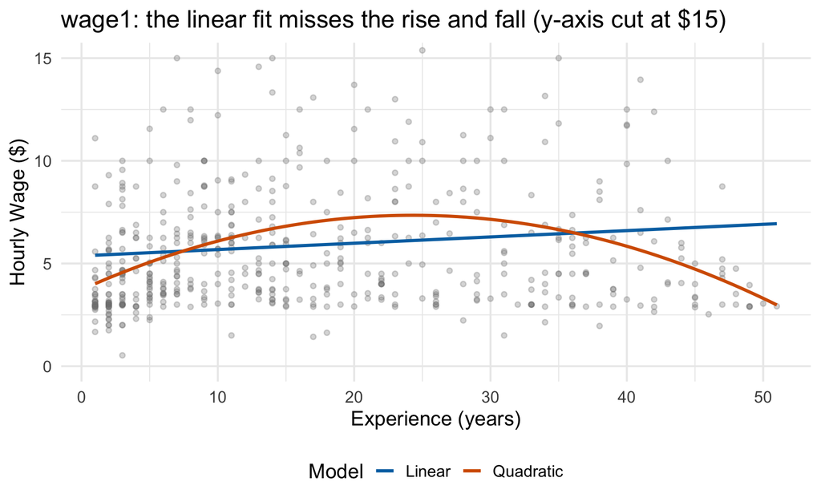

## Interpreting Quadratics

The marginal effect of $X$ on $Y$ is **not constant** — it depends on $X$:

$$\frac{\partial Y}{\partial X} = \beta_1 + 2\beta_2 X$$

With $\hat{\beta}_1 \approx 0.298$ and $\hat{\beta}_2 \approx -0.0061$:

| Experience | Marginal Effect | Interpretation |
| --- | --- | --- |
| 5 years | $0.298 + 2(-0.0061)(5) = 0.24$ | +$0.24/hr per extra year |
| 25 years | $0.298 + 2(-0.0061)(25) ≈ -0.01$ | Just past the peak |
| 40 years | $0.298 + 2(-0.0061)(40) = -0.19$ | −$0.19/hr per extra year |

**Peak:** $x^* = -\frac{\beta_1}{2\beta_2} = -\frac{0.298}{2(-0.0061)} \approx 24$ years

## Higher-Order Polynomials

- Each extra power allows one more bend, e.g., a **cubic**: $Y = \beta_0 + \beta_1 X + \beta_2 X^2 + \beta_3 X^3 + \mu$
- Marginal effect: $\frac{\partial Y}{\partial X} = \beta_1 + 2\beta_2 X + 3\beta_3 X^2$

```r
wage_data <- wage_data |> mutate(exper3 = exper^3)
lm_cubic <- lm(wage ~ exper + exper2 + exper3, data = wage_data)
printCoefmat(coef(summary(lm_cubic)), digits = 3)
```

```
              Estimate Std. Error t value Pr(>|t|)
(Intercept)  3.5995854  0.4538582    7.93  1.3e-14 ***
exper        0.3349321  0.0951907    3.52  0.00047 ***
exper2      -0.0082080  0.0049306   -1.66  0.09657 .
exper3       0.0000300  0.0000701    0.43  0.66830
---
Signif. codes:  0 '***' 0.001 '**' 0.01 '*' 0.05 '.' 0.1 ' ' 1
```

- Is the cubic needed? Test $H_0: \beta_3 = 0$: p = 0.67, and $R^2$ barely moves (0.0928 → 0.0931). The quadratic is enough.
- Rarely go past a cubic: higher powers chase noise and swing wildly near the edges of the data

# Logarithmic Transformations

## Why Use Logs?

- Many economic variables (wages, income, prices) are **right-skewed**
- Logging compresses the right tail → more symmetric distribution

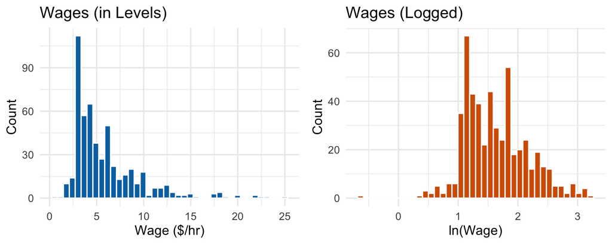

- But more importantly: logs let us talk about **percentage changes**

## From Logs to Percent Changes

We need one key property of logs:

$$\ln(Y_1) - \ln(Y_0) = \ln\!\left(\frac{Y_1}{Y_0}\right) \approx \frac{Y_1 - Y_0}{Y_0}$$

A **difference in logs** $\approx$ the **proportional change** (for small changes)

| Wage Change | Proportional Change | Difference in Logs |
| --- | --- | --- |
| $20 → $21 | $1/20 = 0.050$ | $\ln(21)-\ln(20) = 0.049$ |
| $20 → $22 | $2/20 = 0.100$ | $\ln(22)-\ln(20) = 0.095$ |
| $20 → $25 | $5/20 = 0.250$ | $\ln(25)-\ln(20) = 0.223$ |
| $20 → $50 | $30/20 = 1.500$ | $\ln(50)-\ln(20) = 0.916$ |

Works well for small changes; it breaks down for large ones

## Interpreting the Log-Linear Model

$$\ln(Y) = \beta_0 + \beta_1 X + \mu$$

What happens when $X$ increases by one unit?

**Steps 1–2:** Write the model at $X_0 + 1$ and $X_0$, then subtract:

$$\ln(Y_1) - \ln(Y_0) = [\beta_0 + \beta_1(X_0 + 1)] - [\beta_0 + \beta_1 X_0] = \beta_1$$

**Steps 3–4:** Apply the approximation, then multiply by 100:

$$\frac{Y_1 - Y_0}{Y_0} \approx \beta_1 \quad \Rightarrow \quad \text{% change in } Y \approx 100 \times \beta_1$$

**Log-Linear Interpretation**

A **one-unit** increase in $X$ → approximately $100 \times \beta_1$ **percent** change in $Y$

For big changes (roughly $|\beta_1| > 0.20$), use the exact formula: $100 \times (e^{\beta_1} - 1)$ percent

## Log-Linear: Example

```r
wage1 <- wage1 |> mutate(log_wage = log(wage))
lm_loglin <- lm(log_wage ~ educ, data = wage1)
coef(lm_loglin) |> round(4)
```

```
(Intercept)        educ
     0.5838      0.0827
```

- $\hat{\beta}_1 \approx 0.083$ → one more year of education is associated with ≈ **8.3% higher wages**

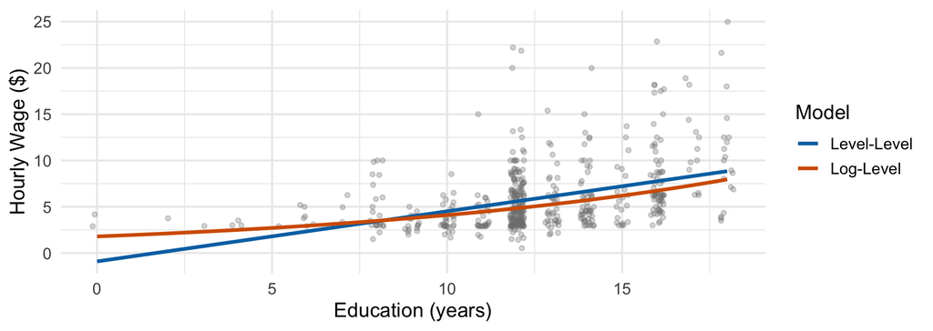

## Other Log Models

| Model | Equation | $X$ changes by… | $Y$ changes by… |
| --- | --- | --- | --- |
| **Level-Level** | $Y = \beta_0 + \beta_1 X$ | 1 unit | $\beta_1$ units |
| **Log-Level** | $\ln(Y) = \beta_0 + \beta_1 X$ | 1 unit | $(100\beta_1)$% |
| **Level-Log** | $Y = \beta_0 + \beta_1\ln(X)$ | 1% | $\beta_1/100$ units |
| **Log-Log** | $\ln(Y) = \beta_0 + \beta_1\ln(X)$ | 1% | $\beta_1$% |

**Quick Rule**

- **Logged** variable → think in **percents**
- **Level** variable → think in **units**

## Log Models: Examples

**Level-Log** (`meap93`)

$\widehat{math10} = -69.3 + 11.16 \cdot \ln(expend)$

Formula: $\Delta Y = \frac{\beta_1}{100} \cdot \%\Delta X$

$\Delta math10 = \frac{11.16}{100} \cdot 1 = 0.11$

1% more spending per student → **0.11 percentage points** higher math pass rate

**Log-Log** (`hprice1`)

$\widehat{\ln(price)} = -0.98 + 0.87 \cdot \ln(sqrft)$

Formula: $\%\Delta Y = \beta_1 \cdot \%\Delta X$

$\%\Delta price = 0.87 \cdot 1 = 0.87\%$

A 1% larger house → **0.87%** higher price

$\beta_1$ is the **elasticity**: a unit-free measure of responsiveness

## When to Use Logs?

**Commonly logged:**

- Wages, income, prices, population, firm revenue, expenditures
- Positive, right-skewed, where % changes are more meaningful

**Typically NOT logged:**

- Education (years), age, rates/percentages, dummy variables
- Variables that can be zero or negative ($\ln(0)$ is undefined!)

**Watch Out**

1. The “$100 \times \beta_1$%” approximation works for small $\beta_1$ (roughly $|\beta_1| < 0.20$). For larger coefficients, use the **exact** formula: $100 \times (e^{\beta_1} - 1)$%
2. Be wary if your pre-logged variable contains negative numbers or zeros!

## Practice 2: Log Models

Name the model and interpret $\hat{\beta}_1$:

1. $\ln(\widehat{wage}) = 1.60 + 0.07 \cdot educ$
2. $\widehat{price} = -595.4 + 99.8 \cdot \ln(lotsize)$, $price$ in $1,000s
3. $\ln(\widehat{salary}) = 4.80 + 0.25 \cdot \ln(sales)$

**Answers:**

1. **Log-level:** 1 more year → ≈ **7%** higher wage
2. **Level-log:** 1% larger lot → $99.8/100 \approx$ **$1,000** higher price
3. **Log-log:** 1% more sales → **0.25%** higher salary (an elasticity)

## The Big Reference Table

| Model | Equation | Interpretation of $\hat{\beta}_1$ |
| --- | --- | --- |
| **Level-Level** | $Y = \beta_0 + \beta_1 X$ | 1-unit ↑ $X$ → $\beta_1$-unit Δ $Y$ |
| **Log-Level** | $\ln(Y) = \beta_0 + \beta_1 X$ | 1-unit ↑ $X$ → $(100\beta_1)$% Δ $Y$ |
| **Level-Log** | $Y = \beta_0 + \beta_1 \ln(X)$ | 1% ↑ $X$ → $\beta_1/100$ unit Δ $Y$ |
| **Log-Log** | $\ln(Y) = \beta_0 + \beta_1 \ln(X)$ | 1% ↑ $X$ → $\beta_1$% Δ $Y$ |
| **Quadratic** | $Y = \beta_0 + \beta_1 X + \beta_2 X^2$ | Marginal effect = $\beta_1 + 2\beta_2 X$ |
| **Dummy** | $Y = \beta_0 + \beta_1 D$ | Diff. between $D=1$ and baseline |
| **Dummy (log)** | $\ln(Y) = \beta_0 + \beta_1 D$ | ≈ $(100\beta_1)$% diff. from baseline |

## Key Takeaways

- **Dummy variables:** shift the intercept; each coefficient is the gap from the omitted **baseline** ($g$ groups → $g - 1$ dummies)
- **Quadratics:** the marginal effect $\beta_1 + 2\beta_2 X$ changes with $X$, peaking (or bottoming out) at $X^* = -\beta_1 / 2\beta_2$; rarely go past a cubic
- **Log-level:** 1-unit ↑ $X$ → ≈ $100\beta_1$% change in $Y$; for big $\beta_1$, use $100(e^{\beta_1} - 1)$%
- **Level-log:** 1% ↑ $X$ → $\beta_1/100$-unit change in $Y$
- **Log-log:** 1% ↑ $X$ → $\beta_1$% change in $Y$ (an **elasticity**)
- **Always ask first:** Is $Y$ logged? Is $X$ logged? That decides the interpretation.

EC325 | Unit 7 | Dummy Variables and Non-Linear Models